# Cooperation among Committees in the German Bundesrat

Annerose Nisser, September 2016

This file analyses the data collected on sessions of the German Bundesrat (Federal Council). I use data that I collected with a Python-based webscraper (combining [Selenium](http://selenium-python.readthedocs.io) and [scrapy](https://scrapy.org)). You find my code [here](https://github.com/annerosenisser/bundesrat/tree/master/bundesrat).

More specifically, it asks two questions:

1. Which are the committees involved in the decision-making process? Which are the most important committees?
2. Which committees tend to cooperate most?

### Data preparation

I’m reading in the data that I collected with the scraper:

```r
# getwd()
yourpath <- "/Users/Annerose/Documents/15-16/Code/bundesrat"
setwd(yourpath)
bundesrat <- read.csv("data/bundesrat_2014-16.csv")
```

I then make sure that the data is read in correctly:

```r
names(bundesrat)
head(bundesrat)
```

[output not shown]

### Which are the important committees?

In the dataset, each decision of the German Bundesrat is saved in one row. The committees involved in a given decision are coded as dummy variables. This signifies that I can easily table in how many decisions each committee was involved during the time period of observation (2014-2016):

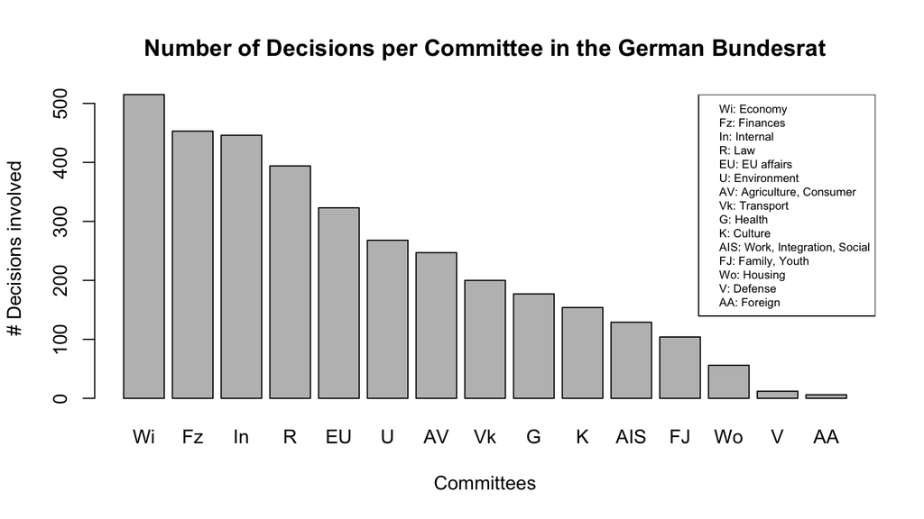

```r
t <- apply(bundesrat[, c(1:15)], 2, sum, na.rm = T)
t <- sort(t, decreasing = T)
barplot(t, xlab = "Committees", ylab = "# Decisions involved",
        main = "Number of Decisions per Committee in the German Bundesrat")
labels <- c("Wi: Economy", "Fz: Finances", "In: Internal", "R: Law", "EU: EU affairs",
            "U: Environment", "AV: Agriculture, Consumer", "Vk: Transport", "G: Health", "K: Culture",
            "AIS: Work, Integration, Social", "FJ: Family, Youth",
            "Wo: Housing", "V: Defense", "AA: Foreign")
legend("topright", labels, cex = 0.6)
```

It seems that the economic (“Wi”), financial (“Fz”) and domestic polity (“In”) committees are clearly the most important ones, i.e. those involved in the largest number of decisions.

But has there been a temporal trend in the importance of committees? To examine this, I run the analysis separately per year.

First, I create a function that will transform and then plot the relevant data (I call this function `bplotfun`):

```r
bplotfun <- function(df, ... ) {
  df <- df[, c(1:15)]
  t <- apply(df, 2, sum, na.rm = T)
  t <- sort(t, decreasing = T)
  barplot(t, xlab = "Committees", ylab = "# Decisions involved",
        # cex.axis = 0.5,
        las = 2, # turn the axis labels
        ...)
}
```

Then I “feed” the function with the relevant data:

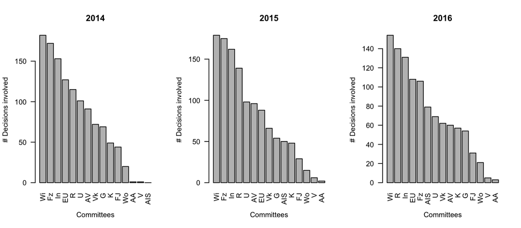

```r
# Make three panes to plot the barplots:
par(mfrow=c(1,3))

for (i in seq(2014, 2016)) {
  bplotfun(df = bundesrat[bundesrat$year==i, ], main = as.character(i))
}
```

As the three figures indicate, the economics committee has been the most important one throughout all three years. However, it is interesting to note that the EU committee was more important than the finance committee in 2016 – this might be explained by the Brexit referendum in June 2016 (?).

### Which committees cooperate most?

To examine which committees cooperate most, I first rely on a simple covariation matrix:

```r
m <- round(cor(bundesrat[, c(1:15)], use = "pairwise.complete.obs",
    method = "pearson"), 3)
head(m, 5)
```

```
##         AA    AIS     AV     EU     FJ     Fz      G     In      K      R
## AA   1.000 -0.019 -0.028 -0.007 -0.017  0.005 -0.023  0.005 -0.021  0.058
## AIS -0.019  1.000 -0.058  0.066  0.132  0.038  0.073  0.026  0.109 -0.025
## AV  -0.028 -0.058  1.000  0.049 -0.042 -0.082  0.112 -0.121 -0.060 -0.083
## EU  -0.007  0.066  0.049  1.000  0.024 -0.118 -0.059  0.045  0.155  0.014
## FJ  -0.017  0.132 -0.042  0.024  1.000 -0.001  0.088  0.145  0.194  0.125
##          U      V     Vk     Wi     Wo
## AA  -0.029 -0.006  0.006 -0.023 -0.012
## AIS -0.024 -0.027 -0.007  0.130  0.040
## AV   0.137 -0.039 -0.046  0.015  0.008
## EU   0.096 -0.047  0.011  0.225 -0.017
## FJ  -0.078  0.005 -0.091  0.009 -0.012
```

It’s difficult to see any pattern from this large table (of which only parts are displayed above). Therefore, I opt instead for a correlation plot. You need to have `corrplot` installed to run this. If not, run `install.packages("corrplot")` to get the package. For more information on the package, see [here](http://www.sthda.com/english/wiki/visualize-correlation-matrix-using-correlogram).

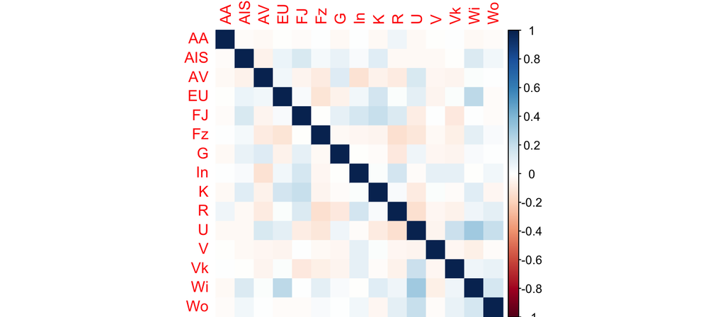

```r
require(corrplot)
corrplot(m, method = "color")
```

It’s still pretty hard to see any pattern in this plot. I see two issues with this plot:

1. Correlations are on average very low, so it’s hard to see any nuances.
2. The data isn’t ordered in increasing or decreasing order of correlation strength.